# Part II - (UsedCarsSA)

## by (Abdulmajeed Duraibi)

## Investigation Overview

In this project I tried to investigate all feature in the UsedCarsSA dataset. I used the Question-Visualization-Observations framework in the investigation process. Here are three visualizations I'll present

1. What is most popular gear type for selling cars? (univariate)
2. Does the price increase by car's year? (Bivariate)
3. Is there relation between Price and Year and Gear Type? (Multivariate)

## Dataset Overview

[Saudi Arabia Used Cars](https://www.kaggle.com/datasets/turkibintalib/saudi-arabia-used-cars-dataset?d) dataset was selected based on Udacity standards.The dataset related to used cars collected from [Syarah](https://syarah.com/) that enables users to sell their cars. The following is a brief description of all the features in the dataset

- Make: Company that makes the car, such: Hyundai, Toyota, Mercedes
- Type: Name of the car, such: Elantra, Camry, CLA
- Year: Model of car, such: 2020, 2021, 2022
- Origin: Options of the car: such saudi options, Gulf arabic
- Color: Color of the car, such: Black, White, Blue
- Options: if Options = full, that means the car have full options
- Engine_Size: such 5.7
- Fuel_Type: such: Gas, Diesel
- Gear_Type: such: Manuel, Automatic
- Mileage: such 103000 in KM
- Region: such Riyadh, Jeddah
- Price: such 114000 SAR
- Negotiable: is price negotiable or not
- Which fuel type is most popular across all regions?

## Proportion of Gear Type

**About 87% of cars used Automatic gear**  
**About 13% of cars used Manual gear**

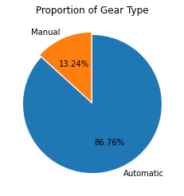

## Car's Year VS Car's Price

**In 1980 and 1990 car's year the average price is high**  
**Since 2000, the average price of cars has increased**

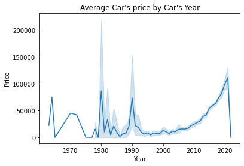

## Average Car's price by Car's Year Group by Gear Type

**The `Automatic` cars is `higher-priced` than `Manual` when car's year increase**

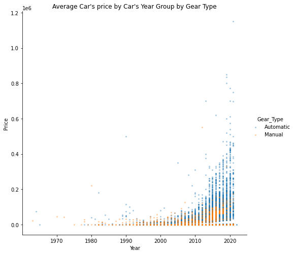